# Quantifying Landscape Pattern

Bri Baker

1/19/2022

```r
frag_classes <- c("noroad_4class", "noroad_8class", "road_4class","road_8class")
frag_lands <- c("noroad_4land", "noroad_8land", "road_4land", "road_8land")

neighbors <- c("4", "8", "4", "8")
levels <- c("noroad", "noroad", "road", "road")


frag_class <- data.frame()
frag_land <- data.frame()

for (i in 1:4){
  class <- paste("week_3/", frag_classes[i], ".csv", sep = "")

  file_class <- read_csv(here(class)) %>%
    clean_names() %>%
    mutate(
      neighbor = neighbors[i],
      level = levels[i]
    )

  frag_class <- rbind(frag_class, file_class)


  land <- paste("week_3/", frag_lands[i], ".csv", sep = "")

  file_land <- read_csv(here(land)) %>%
    clean_names() %>%
    mutate(
      neighbor = neighbors[i],
      level = levels[i]
    )

  frag_land <- rbind(frag_land, file_land)

}
```

```r
land_comp <- frag_land %>%
  filter(
    lid %in% c("tile_0014", "tile_0018", "tile_0022"),
    level == "road"
  ) %>%
  mutate(
    type = case_when(
      lid == "tile_0014" ~ "agricultural",
      lid == "tile_0018" ~ "urbanizing",
      TRUE ~ "rural"
    )
  ) %>%
  select(
    type, neighbor, ed, pr, prd, shei
  ) %>%
  pivot_longer(c(ed, pr, prd, shei))
```

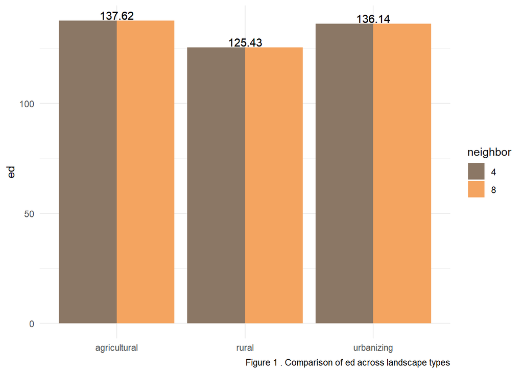

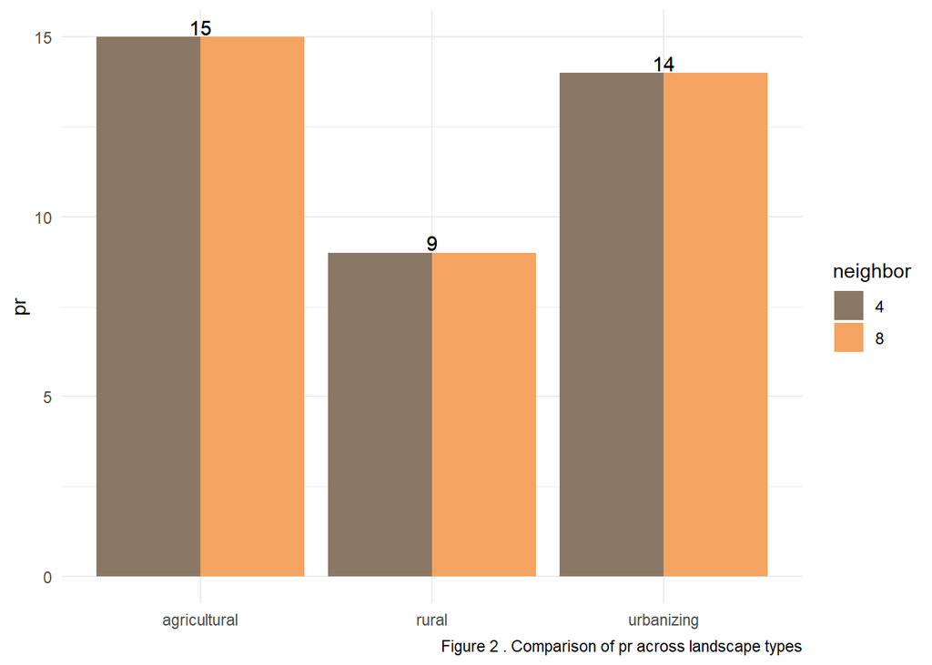

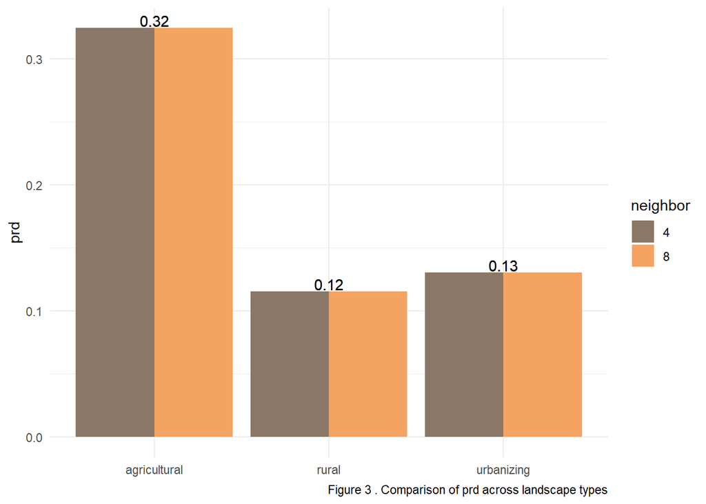

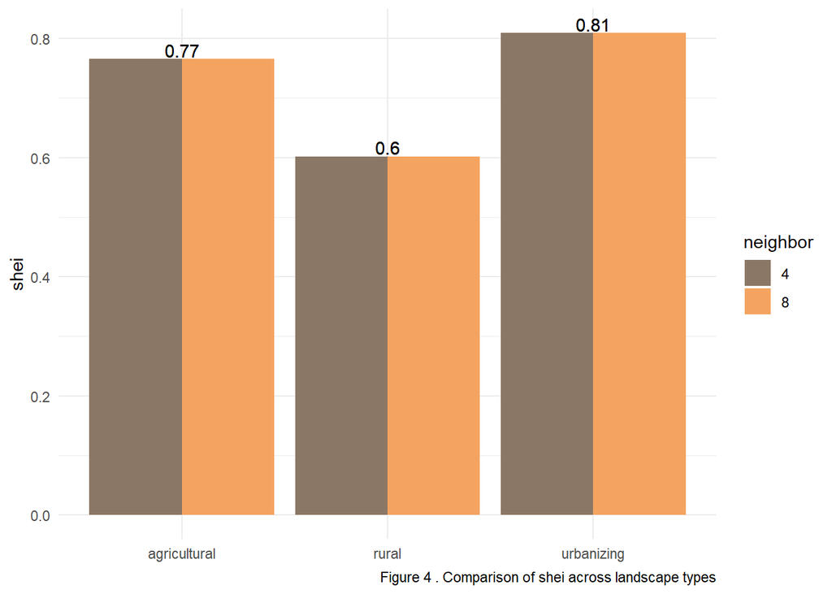

```r
metrics <- c("ed", "pr", "prd", "shei")

plots <- vector("list")

for (i in 1:length(metrics)){
  metric <- metrics[i]

  title <- paste("Figure", i, ". Comparison of", metric, "across landscape types")

  metric_graph <- land_comp %>%
    filter(
      name == metric
    )

  plot <- ggplot(metric_graph, aes(x = type, y = value, fill = neighbor)) +
    geom_col(position = "dodge") +
    labs(y = metric, caption = title) +
    scale_fill_manual(values = c("peachpuff4", "sandybrown"))+
    geom_text(aes(label = round(value, 2)), vjust = -0.15)+
  theme_minimal()+
    theme(
      axis.title.x = element_blank()
    )

  print(plot)

}
```

### Part a.

- *Landscape edge density:* highest in the agricultural landscape type and lowest in the rural type, but fairly similar across the board (Fig 1).
- *Patch richness:* highest in agricultural, similar to agricultural in urbanizing, lowest in rural (Fig 2).
- *Patch richness density:* highest in agricultural, similar in urbanizing and rural, lowest in rural (Fig 3).
- *Shannon evenness index:* highest in urbanizing, similar in agricultural, lowest in rural (Fig 4).

### Part b.

All landscape metrics are the same using the 4 neighbor rule as the 8 neighbor rule.

### Part c.

```r
`%nin%` <- negate(`%in%`)

ed_classes <- frag_class %>%
  filter(
    lid %in% c("tile_0014", "tile_0018", "tile_0022"),
    level == "road",
    neighbor == "4"
  ) %>%
  mutate(
    landscape = case_when(
      lid == "tile_0014" ~ "agricultural",
      lid == "tile_0018" ~ "urbanizing",
      TRUE ~ "rural"
    ),
    cultivation = case_when(
      type %in% c("Mixed Chaparral", "Coastal Oak Woodland", "Annual Grassland", "Valley Foothill Riparian", "Montane Hardwood-Conifer", "Valley Oak Woodland", "Coastal Scrub", "Closed-Cone Pine", "Lacustrine") ~ "natural",
      TRUE ~ "cultivated"
    )
  ) %>%
  select(landscape, cultivation, type, ed) %>%
  mutate(
    cultivation_binary = case_when(
      cultivation == "natural" ~ 0,
      TRUE ~ 1
    )
  ) %>%
  filter(type %nin% c("Barren", "Urban", "Eucalyptus"))

total_ed <- ed_classes %>%
  group_by(cultivation, landscape) %>%
  summarize(sum(ed)) %>%
  pivot_wider(landscape, names_from = cultivation, values_from = `sum(ed)`)

total_ed %>%
  kbl(
    caption = "Table 1. Natural and Cultivated Edge Density of Landscapes"
  ) %>%
  kable_classic()
```

Table 1. Natural and Cultivated Edge Density of Landscapes

| landscape | cultivated | natural |
| --- | --- | --- |
| agricultural | 120.7856 | 91.7344 |
| rural | 6.2021 | 193.2359 |
| urbanizing | 33.9859 | 138.9825 |

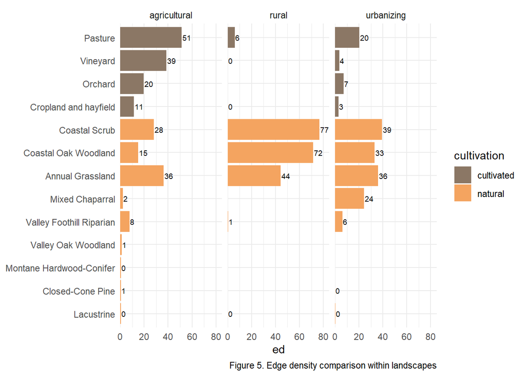

```r
ggplot(ed_classes, aes(x = reorder(reorder(type, ed), cultivation_binary), y = ed, fill = cultivation)) +
  facet_wrap(vars(landscape)) +
  geom_col(position = "dodge") +
  scale_y_continuous(expand = c(0, 0), limits = c(0, 85))+
  coord_flip() +
  labs(
    x = "Type",
    caption = "Figure 5. Edge density comparison within landscapes"
  )+
  scale_fill_manual(values = c("peachpuff4", "sandybrown"))+
  geom_text(aes(label = round(ed)), hjust = -0.1, size = 2.5)+
  theme_minimal()+
    theme(
      axis.title.y = element_blank()
    )
```

The agricultural landscape has the highest edge densities of cultivated classes (sum: 120), followed by urbanizing (sum: 33). Rural has far fewer of the cultivated classes to begin with and has low edge densities in the classes that it does contain (sum: 6) with pasture being the highest.

## Question 2: Including Roads

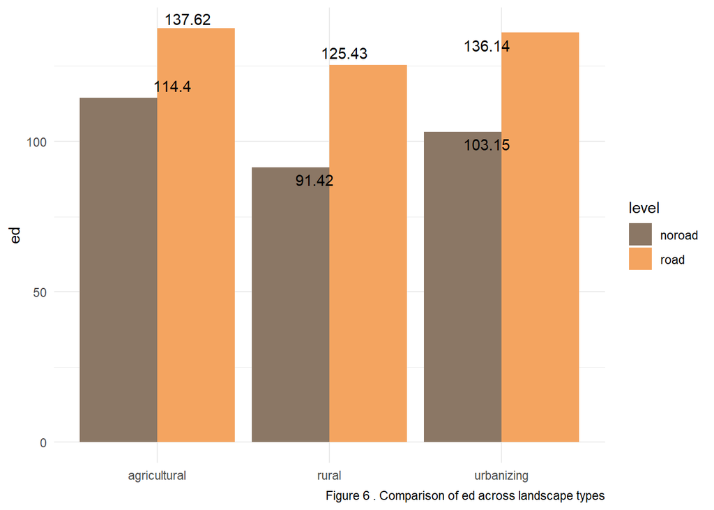

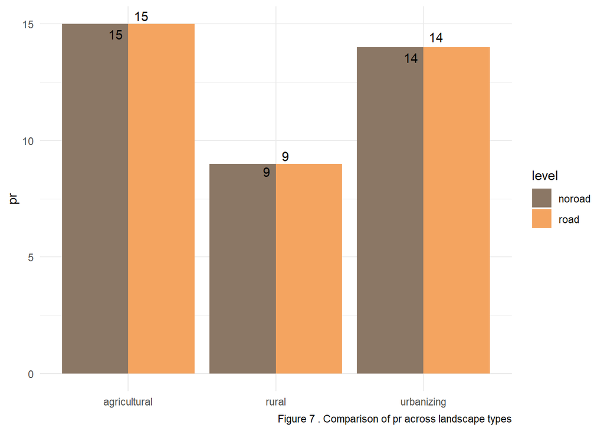

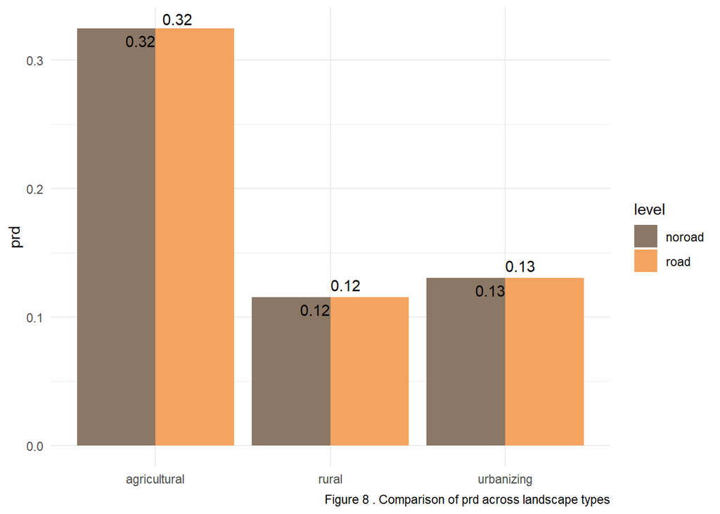

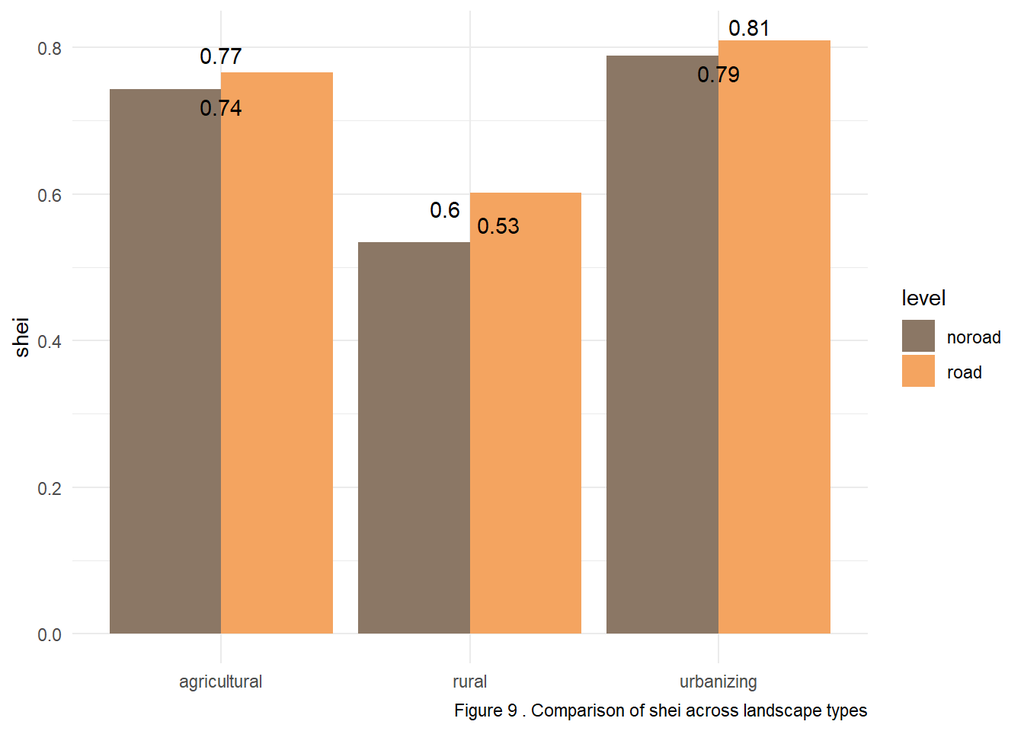

```r
comparison <- frag_land %>%
  filter(
    lid %in% c("tile_0014", "tile_0018", "tile_0022"),
    neighbor == 4
  ) %>%
  mutate(
    type = case_when(
      lid == "tile_0014" ~ "agricultural",
      lid == "tile_0018" ~ "urbanizing",
      TRUE ~ "rural"
    )
  ) %>%
  select(
    level, type, neighbor, ed, pr, prd, shei
  ) %>%
  pivot_longer(c(ed, pr, prd, shei))


for (i in 1:length(metrics)){
  metric <- metrics[i]

  title <- paste("Figure", i+5, ". Comparison of", metric, "across landscape types")

  metric_graph <- comparison %>%
    filter(
      name == metric
    )

  plot <- ggplot(metric_graph, aes(x = type, y = value, fill = level)) +
    geom_col(position = "dodge") +
    labs(y = metric, caption = title) +
    scale_fill_manual(values = c("peachpuff4", "sandybrown"))+
    geom_text_repel(aes(label = round(value,2)))+
  theme_minimal()+
    theme(
      axis.title.x = element_blank()
    )

  print(plot)

}
```

Patch richness and patch richness density are the same whether roads are considered or not (Figure 7, Figure 8).

## Question 3: Applications

The metrics here can be utilized to prioritize landscape types for conservation. For example, a planner might choose to prioritize acquisition of landscapes with a high SHEI or focus their study of the population of a focal species in landscapes with high edge density.